# Optimal Treatment Analysis

## Outcome Variable

**Outcome Variable:** whz

## Predictor Variables

**Intervention Variable:** impsan

**Adjustment Set:**

- arm
- sex
- W_mage
- meducyrs
- feducyrs
- hhwealth_quart
- hfoodsec
- W_mhtcm
- W_nrooms
- W_parity
- impfloor
- safeh20
- delta_W_mage
- delta_meducyrs
- delta_feducyrs
- delta_hhwealth_quart
- delta_hfoodsec
- delta_W_mhtcm
- delta_W_nrooms
- delta_W_parity
- delta_impfloor
- delta_safeh20

## Stratifying Variables

The analysis was stratified on these variable(s):

- agecat
- studyid
- country

## Data Summary

| agecat | studyid | country | impsan | n_cell | n |
| --- | --- | --- | --- | --- | --- |
| Birth | ki0047075b-MAL-ED | BANGLADESH | 1 | 186 | 222 |
| Birth | ki0047075b-MAL-ED | BANGLADESH | 0 | 36 | 222 |
| Birth | ki0047075b-MAL-ED | BRAZIL | 1 | 163 | 167 |
| Birth | ki0047075b-MAL-ED | BRAZIL | 0 | 4 | 167 |
| Birth | ki0047075b-MAL-ED | INDIA | 1 | 90 | 188 |
| Birth | ki0047075b-MAL-ED | INDIA | 0 | 98 | 188 |
| Birth | ki0047075b-MAL-ED | NEPAL | 1 | 165 | 166 |
| Birth | ki0047075b-MAL-ED | NEPAL | 0 | 1 | 166 |
| Birth | ki0047075b-MAL-ED | PERU | 1 | 60 | 243 |
| Birth | ki0047075b-MAL-ED | PERU | 0 | 183 | 243 |
| Birth | ki0047075b-MAL-ED | SOUTH AFRICA | 1 | 2 | 211 |
| Birth | ki0047075b-MAL-ED | SOUTH AFRICA | 0 | 209 | 211 |
| Birth | ki0047075b-MAL-ED | TANZANIA, UNITED REPUBLIC OF | 1 | 0 | 109 |
| Birth | ki0047075b-MAL-ED | TANZANIA, UNITED REPUBLIC OF | 0 | 109 | 109 |
| Birth | ki1017093-NIH-Birth | BANGLADESH | 1 | 9 | 28 |
| Birth | ki1017093-NIH-Birth | BANGLADESH | 0 | 19 | 28 |
| Birth | ki1017093c-NIH-Crypto | BANGLADESH | 1 | 21 | 23 |
| Birth | ki1017093c-NIH-Crypto | BANGLADESH | 0 | 2 | 23 |
| Birth | ki1114097-CONTENT | PERU | 1 | 1 | 2 |
| Birth | ki1114097-CONTENT | PERU | 0 | 1 | 2 |
| Birth | ki1135781-COHORTS | GUATEMALA | 1 | 13 | 208 |
| Birth | ki1135781-COHORTS | GUATEMALA | 0 | 195 | 208 |
| Birth | ki1135781-COHORTS | INDIA | 1 | 1685 | 4461 |
| Birth | ki1135781-COHORTS | INDIA | 0 | 2776 | 4461 |
| Birth | ki1135781-COHORTS | PHILIPPINES | 1 | 177 | 1126 |
| Birth | ki1135781-COHORTS | PHILIPPINES | 0 | 949 | 1126 |
| Birth | kiGH5241-JiVitA-3 | BANGLADESH | 1 | 5300 | 7675 |
| Birth | kiGH5241-JiVitA-3 | BANGLADESH | 0 | 2375 | 7675 |
| Birth | kiGH5241-JiVitA-4 | BANGLADESH | 1 | 131 | 185 |
| Birth | kiGH5241-JiVitA-4 | BANGLADESH | 0 | 54 | 185 |

[output cut: 68 more lines]

The following strata were considered:

- agecat: 24 months, studyid: ki0047075b-MAL-ED, country: BANGLADESH
- agecat: 24 months, studyid: ki0047075b-MAL-ED, country: BRAZIL
- agecat: 24 months, studyid: ki0047075b-MAL-ED, country: INDIA
- agecat: 24 months, studyid: ki0047075b-MAL-ED, country: NEPAL
- agecat: 24 months, studyid: ki0047075b-MAL-ED, country: PERU
- agecat: 24 months, studyid: ki0047075b-MAL-ED, country: SOUTH AFRICA
- agecat: 24 months, studyid: ki0047075b-MAL-ED, country: TANZANIA, UNITED REPUBLIC OF
- agecat: 24 months, studyid: ki1017093-NIH-Birth, country: BANGLADESH
- agecat: 24 months, studyid: ki1017093b-PROVIDE, country: BANGLADESH
- agecat: 24 months, studyid: ki1017093c-NIH-Crypto, country: BANGLADESH
- agecat: 24 months, studyid: ki1114097-CONTENT, country: PERU
- agecat: 24 months, studyid: ki1135781-COHORTS, country: GUATEMALA
- agecat: 24 months, studyid: ki1135781-COHORTS, country: INDIA
- agecat: 24 months, studyid: ki1135781-COHORTS, country: PHILIPPINES
- agecat: 24 months, studyid: ki1148112-LCNI-5, country: MALAWI
- agecat: 24 months, studyid: kiGH5241-JiVitA-3, country: BANGLADESH
- agecat: 24 months, studyid: kiGH5241-JiVitA-4, country: BANGLADESH
- agecat: 6 months, studyid: ki0047075b-MAL-ED, country: BANGLADESH
- agecat: 6 months, studyid: ki0047075b-MAL-ED, country: BRAZIL
- agecat: 6 months, studyid: ki0047075b-MAL-ED, country: INDIA
- agecat: 6 months, studyid: ki0047075b-MAL-ED, country: NEPAL
- agecat: 6 months, studyid: ki0047075b-MAL-ED, country: PERU
- agecat: 6 months, studyid: ki0047075b-MAL-ED, country: SOUTH AFRICA
- agecat: 6 months, studyid: ki0047075b-MAL-ED, country: TANZANIA, UNITED REPUBLIC OF
- agecat: 6 months, studyid: ki1017093-NIH-Birth, country: BANGLADESH
- agecat: 6 months, studyid: ki1017093b-PROVIDE, country: BANGLADESH
- agecat: 6 months, studyid: ki1017093c-NIH-Crypto, country: BANGLADESH
- agecat: 6 months, studyid: ki1114097-CONTENT, country: PERU
- agecat: 6 months, studyid: ki1135781-COHORTS, country: GUATEMALA
- agecat: 6 months, studyid: ki1135781-COHORTS, country: INDIA
- agecat: 6 months, studyid: ki1135781-COHORTS, country: PHILIPPINES
- agecat: 6 months, studyid: ki1148112-LCNI-5, country: MALAWI
- agecat: 6 months, studyid: kiGH5241-JiVitA-3, country: BANGLADESH
- agecat: 6 months, studyid: kiGH5241-JiVitA-4, country: BANGLADESH
- agecat: Birth, studyid: ki0047075b-MAL-ED, country: BANGLADESH
- agecat: Birth, studyid: ki0047075b-MAL-ED, country: BRAZIL
- agecat: Birth, studyid: ki0047075b-MAL-ED, country: INDIA
- agecat: Birth, studyid: ki0047075b-MAL-ED, country: NEPAL
- agecat: Birth, studyid: ki0047075b-MAL-ED, country: PERU
- agecat: Birth, studyid: ki0047075b-MAL-ED, country: SOUTH AFRICA
- agecat: Birth, studyid: ki0047075b-MAL-ED, country: TANZANIA, UNITED REPUBLIC OF
- agecat: Birth, studyid: ki1017093-NIH-Birth, country: BANGLADESH
- agecat: Birth, studyid: ki1017093c-NIH-Crypto, country: BANGLADESH
- agecat: Birth, studyid: ki1114097-CONTENT, country: PERU
- agecat: Birth, studyid: ki1135781-COHORTS, country: GUATEMALA
- agecat: Birth, studyid: ki1135781-COHORTS, country: INDIA
- agecat: Birth, studyid: ki1135781-COHORTS, country: PHILIPPINES
- agecat: Birth, studyid: kiGH5241-JiVitA-3, country: BANGLADESH
- agecat: Birth, studyid: kiGH5241-JiVitA-4, country: BANGLADESH

### Dropped Strata

- agecat: Birth, studyid: ki0047075b-MAL-ED, country: BRAZIL
- agecat: Birth, studyid: ki0047075b-MAL-ED, country: NEPAL
- agecat: Birth, studyid: ki0047075b-MAL-ED, country: SOUTH AFRICA
- agecat: Birth, studyid: ki0047075b-MAL-ED, country: TANZANIA, UNITED REPUBLIC OF
- agecat: Birth, studyid: ki1017093c-NIH-Crypto, country: BANGLADESH
- agecat: Birth, studyid: ki1114097-CONTENT, country: PERU
- agecat: 6 months, studyid: ki0047075b-MAL-ED, country: BRAZIL
- agecat: 6 months, studyid: ki0047075b-MAL-ED, country: NEPAL
- agecat: 6 months, studyid: ki0047075b-MAL-ED, country: SOUTH AFRICA
- agecat: 6 months, studyid: ki0047075b-MAL-ED, country: TANZANIA, UNITED REPUBLIC OF
- agecat: 6 months, studyid: ki1148112-LCNI-5, country: MALAWI
- agecat: 24 months, studyid: ki0047075b-MAL-ED, country: BRAZIL
- agecat: 24 months, studyid: ki0047075b-MAL-ED, country: NEPAL
- agecat: 24 months, studyid: ki0047075b-MAL-ED, country: SOUTH AFRICA
- agecat: 24 months, studyid: ki0047075b-MAL-ED, country: TANZANIA, UNITED REPUBLIC OF
- agecat: 24 months, studyid: ki1148112-LCNI-5, country: MALAWI

## Methods Detail

We’re interested in the causal parameters $E[Y_a]$ for all values of $a \in \mathcal{A}$. These parameters represent the mean outcome if, possibly contrary to fact, we intervened to set all units to have $A=a$. Under the randomization and positivity assumptions, these are identified by the statistical parameters $\psi_a=E_W[E_{Y|A,W}(Y|A=a,W)]$. In addition, we’re interested in the mean of $Y$, $E[Y]$ under no intervention (the observed mean). We will estimate these parameters by using SuperLearner to fit the relevant likelihood factors – $E_{Y|A,W}(Y|A=a,W)$ and $p(A=a|W)$, and then updating our likelihood fit using a joint TMLE.

For unadjusted analyses ($W=\{\}$), initial likelihoods were estimated using Lrnr_glm to estimate the simple $E(Y|A)$ and Lrnr_mean to estimate $p(A)$. For adjusted analyses, a small library containing Lrnr_glmnet, Lrnr_xgboost, and Lrnr_mean was used.

# Results Detail

## Results Plots

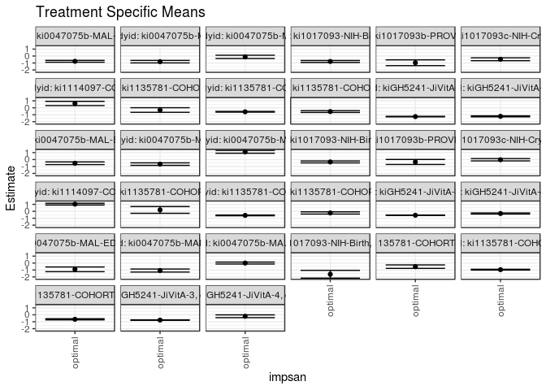

## Results Table

### Parameter: TSM

| agecat | studyid | country | intervention_level | baseline_level | estimate | ci_lower | ci_upper |
| --- | --- | --- | --- | --- | --- | --- | --- |
| Birth | ki0047075b-MAL-ED | BANGLADESH | optimal | observed | -0.9044476 | -1.2414585 | -0.5674367 |
| Birth | ki0047075b-MAL-ED | INDIA | optimal | observed | -1.0796855 | -1.2976137 | -0.8617572 |
| Birth | ki0047075b-MAL-ED | PERU | optimal | observed | -0.0000905 | -0.1425674 | 0.1423864 |
| Birth | ki1017093-NIH-Birth | BANGLADESH | optimal | observed | -1.6136772 | -2.1699879 | -1.0573666 |
| Birth | ki1135781-COHORTS | GUATEMALA | optimal | observed | -0.5179057 | -0.7677627 | -0.2680486 |
| Birth | ki1135781-COHORTS | INDIA | optimal | observed | -0.9516544 | -1.0136205 | -0.8896884 |
| Birth | ki1135781-COHORTS | PHILIPPINES | optimal | observed | -0.6474610 | -0.7284378 | -0.5664843 |
| Birth | kiGH5241-JiVitA-3 | BANGLADESH | optimal | observed | -0.7617201 | -0.7968814 | -0.7265589 |
| Birth | kiGH5241-JiVitA-4 | BANGLADESH | optimal | observed | -0.2093450 | -0.4092352 | -0.0094548 |
| 6 months | ki0047075b-MAL-ED | BANGLADESH | optimal | observed | -0.5294708 | -0.7237562 | -0.3351854 |
| 6 months | ki0047075b-MAL-ED | INDIA | optimal | observed | -0.6566105 | -0.8385399 | -0.4746811 |
| 6 months | ki0047075b-MAL-ED | PERU | optimal | observed | 1.1106965 | 0.9100287 | 1.3113643 |
| 6 months | ki1017093-NIH-Birth | BANGLADESH | optimal | observed | -0.3424707 | -0.4839248 | -0.2010166 |
| 6 months | ki1017093b-PROVIDE | BANGLADESH | optimal | observed | -0.3482352 | -0.7082680 | 0.0117976 |
| 6 months | ki1017093c-NIH-Crypto | BANGLADESH | optimal | observed | -0.0257416 | -0.1935089 | 0.1420257 |
| 6 months | ki1114097-CONTENT | PERU | optimal | observed | 1.0304371 | 0.9065707 | 1.1543035 |
| 6 months | ki1135781-COHORTS | GUATEMALA | optimal | observed | 0.1992800 | -0.2878169 | 0.6863770 |
| 6 months | ki1135781-COHORTS | INDIA | optimal | observed | -0.5881893 | -0.6434248 | -0.5329538 |
| 6 months | ki1135781-COHORTS | PHILIPPINES | optimal | observed | -0.2363513 | -0.3931135 | -0.0795890 |
| 6 months | kiGH5241-JiVitA-3 | BANGLADESH | optimal | observed | -0.5663993 | -0.5994406 | -0.5333580 |
| 6 months | kiGH5241-JiVitA-4 | BANGLADESH | optimal | observed | -0.3161001 | -0.3932651 | -0.2389350 |
| 24 months | ki0047075b-MAL-ED | BANGLADESH | optimal | observed | -0.7559922 | -0.8883493 | -0.6236350 |
| 24 months | ki0047075b-MAL-ED | INDIA | optimal | observed | -0.8093678 | -0.9892410 | -0.6294947 |
| 24 months | ki0047075b-MAL-ED | PERU | optimal | observed | -0.1132842 | -0.3471130 | 0.1205446 |
| 24 months | ki1017093-NIH-Birth | BANGLADESH | optimal | observed | -0.7813046 | -0.9232514 | -0.6393578 |
| 24 months | ki1017093b-PROVIDE | BANGLADESH | optimal | observed | -0.9649998 | -1.3820472 | -0.5479524 |
| 24 months | ki1017093c-NIH-Crypto | BANGLADESH | optimal | observed | -0.4638995 | -0.6713455 | -0.2564534 |
| 24 months | ki1114097-CONTENT | PERU | optimal | observed | 0.6237004 | 0.3169270 | 0.9304737 |
| 24 months | ki1135781-COHORTS | GUATEMALA | optimal | observed | -0.3206651 | -0.6520738 | 0.0107437 |
| 24 months | ki1135781-COHORTS | INDIA | optimal | observed | -0.5755189 | -0.6289398 | -0.5220979 |
| 24 months | ki1135781-COHORTS | PHILIPPINES | optimal | observed | -0.5402872 | -0.6739988 | -0.4065756 |
| 24 months | kiGH5241-JiVitA-3 | BANGLADESH | optimal | observed | -1.2670834 | -1.3081357 | -1.2260310 |
| 24 months | kiGH5241-JiVitA-4 | BANGLADESH | optimal | observed | -1.2319154 | -1.3015069 | -1.1623238 |

### Parameter: E(Y)

| agecat | studyid | country | intervention_level | baseline_level | estimate | ci_lower | ci_upper |
| --- | --- | --- | --- | --- | --- | --- | --- |
| Birth | ki0047075b-MAL-ED | BANGLADESH | observed | observed | -0.9902252 | -1.1311070 | -0.8493435 |
| Birth | ki0047075b-MAL-ED | INDIA | observed | observed | -1.0536702 | -1.1965043 | -0.9108361 |
| Birth | ki0047075b-MAL-ED | PERU | observed | observed | -0.0315638 | -0.1495606 | 0.0864330 |
| Birth | ki1017093-NIH-Birth | BANGLADESH | observed | observed | -1.4239286 | -1.7688028 | -1.0790544 |
| Birth | ki1135781-COHORTS | GUATEMALA | observed | observed | -1.1925000 | -1.3898040 | -0.9951960 |
| Birth | ki1135781-COHORTS | INDIA | observed | observed | -0.9771733 | -1.0119896 | -0.9423570 |
| Birth | ki1135781-COHORTS | PHILIPPINES | observed | observed | -0.6841030 | -0.7582767 | -0.6099293 |
| Birth | kiGH5241-JiVitA-3 | BANGLADESH | observed | observed | -0.7660651 | -0.7930357 | -0.7390946 |
| Birth | kiGH5241-JiVitA-4 | BANGLADESH | observed | observed | -0.2903784 | -0.4497929 | -0.1309639 |
| 6 months | ki0047075b-MAL-ED | BANGLADESH | observed | observed | -0.1354618 | -0.2647919 | -0.0061317 |
| 6 months | ki0047075b-MAL-ED | INDIA | observed | observed | -0.7004578 | -0.8268704 | -0.5740452 |
| 6 months | ki0047075b-MAL-ED | PERU | observed | observed | 1.0376236 | 0.9141918 | 1.1610554 |
| 6 months | ki1017093-NIH-Birth | BANGLADESH | observed | observed | -0.4389101 | -0.5279432 | -0.3498771 |
| 6 months | ki1017093b-PROVIDE | BANGLADESH | observed | observed | -0.2080201 | -0.2927357 | -0.1233045 |
| 6 months | ki1017093c-NIH-Crypto | BANGLADESH | observed | observed | 0.0336790 | -0.0458848 | 0.1132428 |
| 6 months | ki1114097-CONTENT | PERU | observed | observed | 1.0684318 | 0.9515274 | 1.1853362 |
| 6 months | ki1135781-COHORTS | GUATEMALA | observed | observed | -0.0267093 | -0.1562187 | 0.1028002 |
| 6 months | ki1135781-COHORTS | INDIA | observed | observed | -0.7104855 | -0.7428053 | -0.6781657 |
| 6 months | ki1135781-COHORTS | PHILIPPINES | observed | observed | -0.2830286 | -0.3471028 | -0.2189545 |
| 6 months | kiGH5241-JiVitA-3 | BANGLADESH | observed | observed | -0.5891544 | -0.6166626 | -0.5616463 |
| 6 months | kiGH5241-JiVitA-4 | BANGLADESH | observed | observed | -0.3684250 | -0.4392750 | -0.2975751 |
| 24 months | ki0047075b-MAL-ED | BANGLADESH | observed | observed | -0.8208255 | -0.9429246 | -0.6987264 |
| 24 months | ki0047075b-MAL-ED | INDIA | observed | observed | -0.9496667 | -1.0657716 | -0.8335618 |
| 24 months | ki0047075b-MAL-ED | PERU | observed | observed | 0.1064286 | -0.0147106 | 0.2275677 |
| 24 months | ki1017093-NIH-Birth | BANGLADESH | observed | observed | -0.9115790 | -1.0095022 | -0.8136559 |
| 24 months | ki1017093b-PROVIDE | BANGLADESH | observed | observed | -0.8896187 | -0.9726240 | -0.8066134 |
| 24 months | ki1017093c-NIH-Crypto | BANGLADESH | observed | observed | -0.6115706 | -0.7075788 | -0.5155624 |
| 24 months | ki1114097-CONTENT | PERU | observed | observed | 0.5668293 | 0.4302437 | 0.7034148 |
| 24 months | ki1135781-COHORTS | GUATEMALA | observed | observed | -0.5737819 | -0.6582809 | -0.4892829 |
| 24 months | ki1135781-COHORTS | INDIA | observed | observed | -0.6606874 | -0.6938402 | -0.6275347 |
| 24 months | ki1135781-COHORTS | PHILIPPINES | observed | observed | -0.6564149 | -0.7144543 | -0.5983756 |
| 24 months | kiGH5241-JiVitA-3 | BANGLADESH | observed | observed | -1.2911038 | -1.3236793 | -1.2585284 |
| 24 months | kiGH5241-JiVitA-4 | BANGLADESH | observed | observed | -1.2302244 | -1.2892920 | -1.1711567 |

### Parameter: PAR

| agecat | studyid | country | intervention_level | baseline_level | estimate | ci_lower | ci_upper |
| --- | --- | --- | --- | --- | --- | --- | --- |
| Birth | ki0047075b-MAL-ED | BANGLADESH | optimal | observed | -0.0857776 | -0.3885566 | 0.2170014 |
| Birth | ki0047075b-MAL-ED | INDIA | optimal | observed | 0.0260153 | -0.1352517 | 0.1872822 |
| Birth | ki0047075b-MAL-ED | PERU | optimal | observed | -0.0314733 | -0.0951084 | 0.0321619 |
| Birth | ki1017093-NIH-Birth | BANGLADESH | optimal | observed | 0.1897486 | -0.1320048 | 0.5115021 |
| Birth | ki1135781-COHORTS | GUATEMALA | optimal | observed | -0.6745943 | -0.8914090 | -0.4577797 |
| Birth | ki1135781-COHORTS | INDIA | optimal | observed | -0.0255188 | -0.0752845 | 0.0242468 |
| Birth | ki1135781-COHORTS | PHILIPPINES | optimal | observed | -0.0366420 | -0.0704282 | -0.0028558 |
| Birth | kiGH5241-JiVitA-3 | BANGLADESH | optimal | observed | -0.0043450 | -0.0240368 | 0.0153467 |
| Birth | kiGH5241-JiVitA-4 | BANGLADESH | optimal | observed | -0.0810334 | -0.1834774 | 0.0214107 |
| 6 months | ki0047075b-MAL-ED | BANGLADESH | optimal | observed | 0.3940090 | 0.2126404 | 0.5753777 |
| 6 months | ki0047075b-MAL-ED | INDIA | optimal | observed | -0.0438473 | -0.1858271 | 0.0981325 |
| 6 months | ki0047075b-MAL-ED | PERU | optimal | observed | -0.0730729 | -0.2317153 | 0.0855694 |
| 6 months | ki1017093-NIH-Birth | BANGLADESH | optimal | observed | -0.0964394 | -0.2097146 | 0.0168358 |
| 6 months | ki1017093b-PROVIDE | BANGLADESH | optimal | observed | 0.1402151 | -0.2093733 | 0.4898035 |
| 6 months | ki1017093c-NIH-Crypto | BANGLADESH | optimal | observed | 0.0594205 | -0.0823926 | 0.2012337 |
| 6 months | ki1114097-CONTENT | PERU | optimal | observed | 0.0379947 | 0.0005668 | 0.0754225 |
| 6 months | ki1135781-COHORTS | GUATEMALA | optimal | observed | -0.2259893 | -0.7029740 | 0.2509954 |
| 6 months | ki1135781-COHORTS | INDIA | optimal | observed | -0.1222962 | -0.1682296 | -0.0763629 |
| 6 months | ki1135781-COHORTS | PHILIPPINES | optimal | observed | -0.0466773 | -0.1916388 | 0.0982842 |
| 6 months | kiGH5241-JiVitA-3 | BANGLADESH | optimal | observed | -0.0227551 | -0.0394040 | -0.0061062 |
| 6 months | kiGH5241-JiVitA-4 | BANGLADESH | optimal | observed | -0.0523250 | -0.0961255 | -0.0085244 |
| 24 months | ki0047075b-MAL-ED | BANGLADESH | optimal | observed | -0.0648333 | -0.1208377 | -0.0088289 |
| 24 months | ki0047075b-MAL-ED | INDIA | optimal | observed | -0.1402988 | -0.2674406 | -0.0131571 |
| 24 months | ki0047075b-MAL-ED | PERU | optimal | observed | 0.2197128 | 0.0181044 | 0.4213211 |
| 24 months | ki1017093-NIH-Birth | BANGLADESH | optimal | observed | -0.1302745 | -0.2365118 | -0.0240371 |
| 24 months | ki1017093b-PROVIDE | BANGLADESH | optimal | observed | 0.0753811 | -0.3327096 | 0.4834718 |
| 24 months | ki1017093c-NIH-Crypto | BANGLADESH | optimal | observed | -0.1476711 | -0.3338810 | 0.0385388 |
| 24 months | ki1114097-CONTENT | PERU | optimal | observed | -0.0568711 | -0.3557180 | 0.2419759 |
| 24 months | ki1135781-COHORTS | GUATEMALA | optimal | observed | -0.2531168 | -0.5817711 | 0.0755374 |
| 24 months | ki1135781-COHORTS | INDIA | optimal | observed | -0.0851686 | -0.1270903 | -0.0432468 |
| 24 months | ki1135781-COHORTS | PHILIPPINES | optimal | observed | -0.1161277 | -0.2413878 | 0.0091324 |
| 24 months | kiGH5241-JiVitA-3 | BANGLADESH | optimal | observed | -0.0240205 | -0.0460891 | -0.0019518 |
| 24 months | kiGH5241-JiVitA-4 | BANGLADESH | optimal | observed | 0.0016910 | -0.0312464 | 0.0346284 |